# Simple Classification Model for the Sonar Dataset with R

David Lowe

March 13, 2018

Template Credit: Adapted from template made available by Dr. Jason Brownlee of Machine Learning Mastery (http://machinelearningmastery.com/)

For more information on this case study project, please consult Dr. Brownlee’s blog post at https://machinelearningmastery.com/standard-machine-learning-datasets/.

Dataset Used: Connectionist Bench (Sonar, Mines vs. Rocks) Data Set ML Model: Classification, numeric inputs Dataset Reference: https://archive.ics.uci.edu/ml/datasets/Connectionist+Bench+%28Sonar%2C+Mines+vs.+Rocks%29

The Sonar Dataset involves the prediction of whether or not an object is a mine or a rock given the strength of sonar returns at different angles. It is a binary (2-class) classification problem.

The purpose of this project is to analyze a dataset using various machine learning algorithms and to document the steps using a template. The project aims to touch on the following areas:

Working through machine learning problems from end-to-end requires a structured modeling approach. Working problems through a project template can encourage you to think about the problem more critically, to challenge your assumptions, and to get good at all parts of a modeling project.

Any predictive modeling machine learning project can be broken down into about 6 common tasks:

1. Define Problem
2. Summarize Data
3. Prepare Data
4. Evaluate Algorithms
5. Improve Accuracy or Results
6. Finalize Model and Present Results

We will compare several different algorithms and determine which one would yield the best results.

## 1. Prepare Problem

### 1.a) Load libraries

```r
library(mlbench)
library(caret)
```

### 1.b) Load dataset

This steps loads the data file. There are 60 attributes, and each column represents a measurement. Since the columns bear no meaningful information, we will not supply the column names to each attribute.

```r
data(Sonar)
```

### 1.c) Split-out validation dataset

Normally, we would create a training (variable name “dataset”) and a validation (variable name “validation”) dataset. Because this dataset is small, we will opt to test the algorithms with the full set of data and not splitting.

```r
dataset <- Sonar
```

## 2. Summarize Data

To gain a better understanding of the data that we have on-hand, we will leverage a number of descriptive statistics and data visualization techniques. The plan is to use the results to consider new questions, review assumptions, and validate hypotheses that we can investigate later with specialized models.

### 2.a) Descriptive statistics

#### 2.a.i) Dimensions of the dataset.

We have 208 rows of data records with 61 columns of attributes. One of the 61 attributes is the class attribute.

```r
dim(dataset)
```

```
## [1] 208  61
```

#### 2.a.ii) Types of the attributes.

```r
sapply(dataset, class)
```

```
##        V1        V2        V3        V4        V5        V6        V7
## "numeric" "numeric" "numeric" "numeric" "numeric" "numeric" "numeric"
##        V8        V9       V10       V11       V12       V13       V14
## "numeric" "numeric" "numeric" "numeric" "numeric" "numeric" "numeric"
##       V15       V16       V17       V18       V19       V20       V21
## "numeric" "numeric" "numeric" "numeric" "numeric" "numeric" "numeric"
##       V22       V23       V24       V25       V26       V27       V28
## "numeric" "numeric" "numeric" "numeric" "numeric" "numeric" "numeric"
##       V29       V30       V31       V32       V33       V34       V35
## "numeric" "numeric" "numeric" "numeric" "numeric" "numeric" "numeric"
##       V36       V37       V38       V39       V40       V41       V42
## "numeric" "numeric" "numeric" "numeric" "numeric" "numeric" "numeric"
##       V43       V44       V45       V46       V47       V48       V49
## "numeric" "numeric" "numeric" "numeric" "numeric" "numeric" "numeric"
##       V50       V51       V52       V53       V54       V55       V56
## "numeric" "numeric" "numeric" "numeric" "numeric" "numeric" "numeric"
##       V57       V58       V59       V60     Class
## "numeric" "numeric" "numeric" "numeric"  "factor"
```

#### 2.a.iii) Peek at the data itself.

```r
head(dataset, n=20)
```

```
##        V1     V2     V3     V4     V5     V6     V7     V8     V9    V10
## 1  0.0200 0.0371 0.0428 0.0207 0.0954 0.0986 0.1539 0.1601 0.3109 0.2111
## 2  0.0453 0.0523 0.0843 0.0689 0.1183 0.2583 0.2156 0.3481 0.3337 0.2872
## 3  0.0262 0.0582 0.1099 0.1083 0.0974 0.2280 0.2431 0.3771 0.5598 0.6194
## 4  0.0100 0.0171 0.0623 0.0205 0.0205 0.0368 0.1098 0.1276 0.0598 0.1264
## 5  0.0762 0.0666 0.0481 0.0394 0.0590 0.0649 0.1209 0.2467 0.3564 0.4459
## 6  0.0286 0.0453 0.0277 0.0174 0.0384 0.0990 0.1201 0.1833 0.2105 0.3039
## 7  0.0317 0.0956 0.1321 0.1408 0.1674 0.1710 0.0731 0.1401 0.2083 0.3513
## 8  0.0519 0.0548 0.0842 0.0319 0.1158 0.0922 0.1027 0.0613 0.1465 0.2838
## 9  0.0223 0.0375 0.0484 0.0475 0.0647 0.0591 0.0753 0.0098 0.0684 0.1487
## 10 0.0164 0.0173 0.0347 0.0070 0.0187 0.0671 0.1056 0.0697 0.0962 0.0251
## 11 0.0039 0.0063 0.0152 0.0336 0.0310 0.0284 0.0396 0.0272 0.0323 0.0452
## 12 0.0123 0.0309 0.0169 0.0313 0.0358 0.0102 0.0182 0.0579 0.1122 0.0835
## 13 0.0079 0.0086 0.0055 0.0250 0.0344 0.0546 0.0528 0.0958 0.1009 0.1240
## 14 0.0090 0.0062 0.0253 0.0489 0.1197 0.1589 0.1392 0.0987 0.0955 0.1895
```

[output cut: 132 more lines]

#### 2.a.iv) Levels of the class attribute.

```r
# split input and output
x <- dataset[,1:60]
y <- dataset[,61]
# class distribution
cbind(freq=table(y), percentage=prop.table(table(y))*100)
```

```
##   freq percentage
## M  111   53.36538
## R   97   46.63462
```

#### 2.a.v) Summarize correlations between input variables.

```r
cor(x)
```

```
##              V1           V2          V3          V4            V5
## V1   1.00000000  0.735895604  0.57153661  0.49143751  0.3447966545
## V2   0.73589560  1.000000000  0.77991587  0.60668448  0.4196689664
## V3   0.57153661  0.779915872  1.00000000  0.78178597  0.5461413777
## V4   0.49143751  0.606684483  0.78178597  1.00000000  0.7269434669
## V5   0.34479665  0.419668966  0.54614138  0.72694347  1.0000000000
## V6   0.23892107  0.332329200  0.34627494  0.35280540  0.5970527386
## V7   0.26081453  0.279040345  0.19043423  0.24644025  0.3354218138
## V8   0.35552318  0.334615160  0.23788409  0.24674201  0.2040055949
## V9   0.35341992  0.316733233  0.25269107  0.24707771  0.1779057756
## V10  0.31827577  0.270781717  0.21963737  0.23776860  0.1832186481
## V11  0.34405764  0.297064686  0.27461039  0.27188142  0.2316836674
## V12  0.21086119  0.194102177  0.21480700  0.17538061  0.2116571016
## V13  0.21072220  0.249595669  0.25876684  0.21575445  0.2990864387
## V14  0.25627774  0.273170131  0.29172413  0.28670752  0.3590619268
## V15  0.30487810  0.307599462  0.28566302  0.27852925  0.3180591864
## V16  0.23907924  0.261844403  0.23701680  0.24824531  0.3287248282
## V17  0.13784532  0.152169829  0.20109316  0.22320254  0.3264772001
## V18  0.04181749  0.042870375  0.12058709  0.19499189  0.2992659908
## V19  0.05522719  0.040910750  0.09930269  0.18940451  0.3405427387
## V20  0.15675978  0.102427625  0.10311719  0.18831690  0.2857371797
## V21  0.11766322  0.075255287  0.06399017  0.14227081  0.2050881801
## V22 -0.05697322 -0.074157218 -0.02681541  0.03600979  0.1528972039
## V23 -0.16342609 -0.179365290 -0.07340016 -0.02974889  0.0739338154
## V24 -0.21809295 -0.196468706 -0.08538025 -0.10297545 -0.0006243906
## V25 -0.29568341 -0.295302419 -0.21425552 -0.20667281 -0.0672964511
## V26 -0.34286494 -0.365748651 -0.29197382 -0.29135704 -0.1256746623
## V27 -0.34170284 -0.337045717 -0.26311108 -0.29474927 -0.1696177701
## V28 -0.22433952 -0.234385972 -0.25667412 -0.25607395 -0.2146921331
## V29 -0.19909875 -0.228490066 -0.29072811 -0.30047629 -0.2838627507
## V30 -0.07742953 -0.115300621 -0.19749312 -0.23660196 -0.2733503204
## V31 -0.04836991 -0.055861646 -0.10619814 -0.19008554 -0.2143362389
## V32 -0.03044373 -0.049682757 -0.10989504 -0.16998661 -0.1734847703
## V33 -0.03193868 -0.108271842 -0.17067139 -0.16465054 -0.2005858455
## V34  0.03131891 -0.004247171 -0.09940851 -0.08396476 -0.1405589889
## V35  0.09811823  0.115823615  0.01705343  0.01520006 -0.0865286684
## V36  0.08072167  0.132610847  0.05306989  0.03928237 -0.0734805606
## V37  0.11956546  0.169185954  0.10752983  0.06348570 -0.0646169136
## V38  0.20987338  0.217493567  0.13027599  0.08988690 -0.0086204624
## V39  0.20837105  0.186828029  0.11049866  0.08934585  0.0634082531
```

[output cut: 677 more lines]

```
## V46  0.17818183  0.16212509  0.237890366  0.205290771  0.180690938
## V47  0.14604206  0.15781492  0.240470822  0.209045200  0.139726958
## V48  0.21905218  0.19681363  0.270197973  0.221425138  0.123666138
## V49  0.15518623  0.17309819  0.328238383  0.209151854  0.088640372
## V50  0.23505309  0.20160902  0.342865811  0.178117857  0.139944497
## V51  0.20975155  0.19140706  0.325665197  0.317941636  0.246764485
## V52  0.20312074  0.19126402  0.309673309  0.298710741  0.195378585
## V53  0.42158848  0.30819693  0.370763799  0.346094935  0.280780235
## V54  0.39737788  0.36144280  0.404116676  0.447117864  0.283470795
## V55  0.42994818  0.38720438  0.503464861  0.453658123  0.264399201
## V56  1.00000000  0.51515432  0.463659327  0.430803621  0.349449360
## V57  0.51515432  1.00000000  0.509804942  0.431295271  0.287218633
## V58  0.46365933  0.50980494  1.000000000  0.550234975  0.329826737
## V59  0.43080362  0.43129527  0.550234975  1.000000000  0.642872023
## V60  0.34944936  0.28721863  0.329826737  0.642872023  1.000000000
```

#### 2.a.vi) Statistical summary of all attributes.

```r
summary(dataset)
```

```
##        V1                V2                V3                V4
##  Min.   :0.00150   Min.   :0.00060   Min.   :0.00150   Min.   :0.00580
##  1st Qu.:0.01335   1st Qu.:0.01645   1st Qu.:0.01895   1st Qu.:0.02438
##  Median :0.02280   Median :0.03080   Median :0.03430   Median :0.04405
##  Mean   :0.02916   Mean   :0.03844   Mean   :0.04383   Mean   :0.05389
##  3rd Qu.:0.03555   3rd Qu.:0.04795   3rd Qu.:0.05795   3rd Qu.:0.06450
##  Max.   :0.13710   Max.   :0.23390   Max.   :0.30590   Max.   :0.42640
##        V5                V6                V7               V8
##  Min.   :0.00670   Min.   :0.01020   Min.   :0.0033   Min.   :0.00550
##  1st Qu.:0.03805   1st Qu.:0.06703   1st Qu.:0.0809   1st Qu.:0.08042
##  Median :0.06250   Median :0.09215   Median :0.1070   Median :0.11210
##  Mean   :0.07520   Mean   :0.10457   Mean   :0.1217   Mean   :0.13480
##  3rd Qu.:0.10028   3rd Qu.:0.13412   3rd Qu.:0.1540   3rd Qu.:0.16960
##  Max.   :0.40100   Max.   :0.38230   Max.   :0.3729   Max.   :0.45900
##        V9               V10              V11              V12
##  Min.   :0.00750   Min.   :0.0113   Min.   :0.0289   Min.   :0.0236
##  1st Qu.:0.09703   1st Qu.:0.1113   1st Qu.:0.1293   1st Qu.:0.1335
##  Median :0.15225   Median :0.1824   Median :0.2248   Median :0.2490
##  Mean   :0.17800   Mean   :0.2083   Mean   :0.2360   Mean   :0.2502
##  3rd Qu.:0.23342   3rd Qu.:0.2687   3rd Qu.:0.3016   3rd Qu.:0.3312
##  Max.   :0.68280   Max.   :0.7106   Max.   :0.7342   Max.   :0.7060
##       V13              V14              V15              V16
##  Min.   :0.0184   Min.   :0.0273   Min.   :0.0031   Min.   :0.0162
##  1st Qu.:0.1661   1st Qu.:0.1752   1st Qu.:0.1646   1st Qu.:0.1963
##  Median :0.2640   Median :0.2811   Median :0.2817   Median :0.3047
##  Mean   :0.2733   Mean   :0.2966   Mean   :0.3202   Mean   :0.3785
##  3rd Qu.:0.3513   3rd Qu.:0.3862   3rd Qu.:0.4529   3rd Qu.:0.5357
##  Max.   :0.7131   Max.   :0.9970   Max.   :1.0000   Max.   :0.9988
##       V17              V18              V19              V20
##  Min.   :0.0349   Min.   :0.0375   Min.   :0.0494   Min.   :0.0656
##  1st Qu.:0.2059   1st Qu.:0.2421   1st Qu.:0.2991   1st Qu.:0.3506
##  Median :0.3084   Median :0.3683   Median :0.4350   Median :0.5425
##  Mean   :0.4160   Mean   :0.4523   Mean   :0.5048   Mean   :0.5630
##  3rd Qu.:0.6594   3rd Qu.:0.6791   3rd Qu.:0.7314   3rd Qu.:0.8093
##  Max.   :1.0000   Max.   :1.0000   Max.   :1.0000   Max.   :1.0000
##       V21              V22              V23              V24
##  Min.   :0.0512   Min.   :0.0219   Min.   :0.0563   Min.   :0.0239
##  1st Qu.:0.3997   1st Qu.:0.4069   1st Qu.:0.4502   1st Qu.:0.5407
##  Median :0.6177   Median :0.6649   Median :0.6997   Median :0.6985
##  Mean   :0.6091   Mean   :0.6243   Mean   :0.6470   Mean   :0.6727
```

[output cut: 57 more lines]

```
##  Max.   :0.039000   Max.   :0.035200   Max.   :0.04470
##       V56                V57               V58
##  Min.   :0.000400   Min.   :0.00030   Min.   :0.000300
##  1st Qu.:0.004400   1st Qu.:0.00370   1st Qu.:0.003600
##  Median :0.006850   Median :0.00595   Median :0.005800
##  Mean   :0.008222   Mean   :0.00782   Mean   :0.007949
##  3rd Qu.:0.010575   3rd Qu.:0.01043   3rd Qu.:0.010350
##  Max.   :0.039400   Max.   :0.03550   Max.   :0.044000
##       V59                V60           Class
##  Min.   :0.000100   Min.   :0.000600   M:111
##  1st Qu.:0.003675   1st Qu.:0.003100   R: 97
##  Median :0.006400   Median :0.005300
##  Mean   :0.007941   Mean   :0.006507
##  3rd Qu.:0.010325   3rd Qu.:0.008525
##  Max.   :0.036400   Max.   :0.043900
```

### 2.b) Data visualizations

#### 2.b.i) Univariate plots to better understand each attribute.

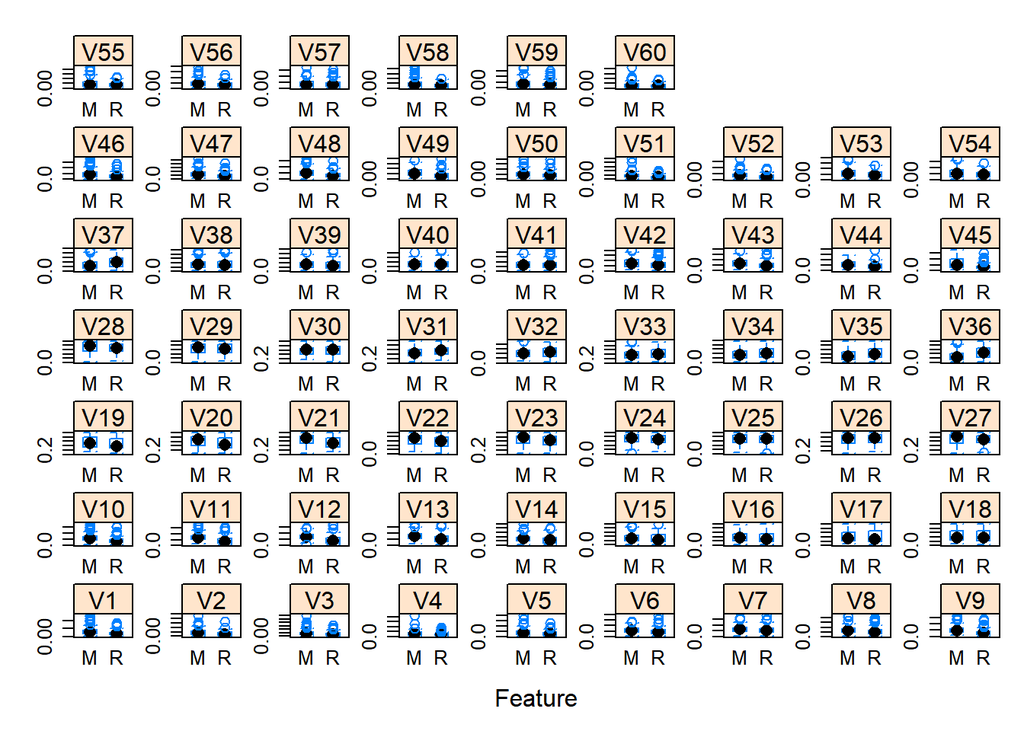

```r
# Box and whisker plots for each attribute
scales <- list(x=list(relation="free"), y=list(relation="free"))
featurePlot(x=x, y=y, plot="box", scales=scales)
```

#### 2.b.ii) Multivariate plots to better understand the relationships between attributes

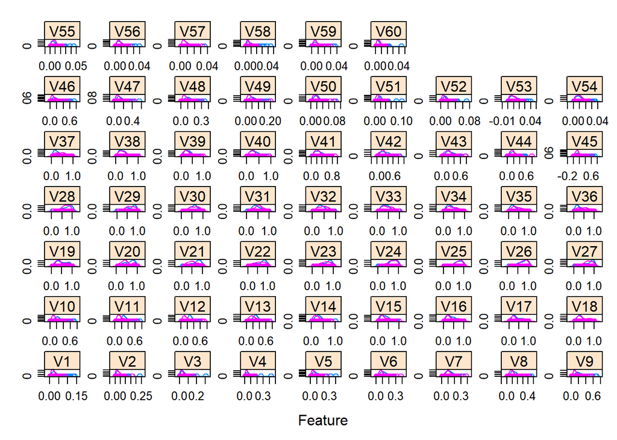

```r
# Density plots for each attribute by class value
featurePlot(x=x, y=y, plot="density", scales=scales)
```

## 3. Prepare Data

Some dataset may require additional preparation activities that will best exposes the structure of the problem and the relationships between the input attributes and the output variable. Some data-prep tasks might include:

- Cleaning data by removing duplicates, marking missing values and even imputing missing values.
- Feature selection where redundant features may be removed.
- Data transforms where attributes are scaled or redistributed in order to best expose the structure of the problem later to learning algorithms.

### 3.a) Data Cleaning

```r
# Not applicable for this iteration of the project.
```

### 3.b) Feature Selection

```r
# Not applicable for this iteration of the project.
```

### 3.c) Data Transforms

```r
dataset[,1:60] <- scale(dataset[,1:60])
```

After the data-prep, we next work on finding a workable model by evaluating a subset of machine learning algorithms that are good at exploiting the structure of the dataset. The typical evaluation tasks include:

- Defining test options such as cross validation and the evaluation metric to use.
- Spot checking a suite of linear and nonlinear machine learning algorithms.
- Comparing the estimated accuracy of algorithms.

Linear Algorithms: Generalized Linear Regression (GLM) and Linear Discriminant Analysis (LDA)

Nonliear Algorithms: Classification and Regression Trees (CART), k-Nearest Neighbors (KNN), and Support Vector Machine (SVM)

The random number seed is reset before each run to ensure that the evaluation of each algorithm is performed using the same data splits. It ensures the results are directly comparable.

### 4.a) Test options and evaluation metric

```r
# Run algorithms using 10-fold cross validation
control <- trainControl(method="repeatedcv", number=10, repeats=3)
metricTarget <- "Accuracy"
```

### 4.b) Generate Models using Algorithms

```r
# GLM
seed_num <- 888
set.seed(seed_num)
fit.glm <- train(Class~., data=dataset, method="glm", metric=metricTarget, trControl=control)
# LDA
set.seed(seed_num)
fit.lda <- train(Class~., data=dataset, method="lda", metric=metricTarget, trControl=control)
# SVM
set.seed(seed_num)
fit.svm <- train(Class~., data=dataset, method="svmRadial", metric=metricTarget, trControl=control)
# CART
set.seed(seed_num)
fit.cart <- train(Class~., data=dataset, method="rpart", metric=metricTarget, trControl=control)
# kNN
set.seed(seed_num)
fit.knn <- train(Class~., data=dataset, method="knn", metric=metricTarget, trControl=control)
```

### 4.c) Compare Algorithms

```r
# No Transformation on the dataset
results <- resamples(list(GLM=fit.glm, LDA=fit.lda, CART=fit.cart, KNN=fit.knn, SVM=fit.svm))
summary(results)
```

```
##
## Call:
## summary.resamples(object = results)
##
## Models: GLM, LDA, CART, KNN, SVM
## Number of resamples: 30
##
## Accuracy
##           Min.   1st Qu.    Median      Mean   3rd Qu.      Max. NA's
## GLM  0.5500000 0.6500000 0.7619048 0.7242641 0.7931818 0.9000000    0
## LDA  0.5000000 0.7000000 0.7207792 0.7418038 0.8095238 0.9047619    0
## CART 0.4761905 0.6666667 0.7142857 0.7072150 0.7619048 0.9000000    0
## KNN  0.6666667 0.7619048 0.8095238 0.8189827 0.8571429 0.9523810    0
## SVM  0.6666667 0.7619048 0.8095238 0.8095310 0.8553571 0.9523810    0
##
## Kappa
##             Min.   1st Qu.    Median      Mean   3rd Qu.      Max. NA's
## GLM   0.13461538 0.2745536 0.5161290 0.4434648 0.5751754 0.7979798    0
## LDA   0.02912621 0.3814433 0.4437500 0.4820402 0.6146789 0.8108108    0
## CART -0.06451613 0.3241273 0.4166167 0.4094713 0.5333333 0.7979798    0
## KNN   0.33484163 0.5161290 0.6146789 0.6317358 0.7161988 0.9041096    0
## SVM   0.30985915 0.5269985 0.6164304 0.6153122 0.7072581 0.9041096    0
```

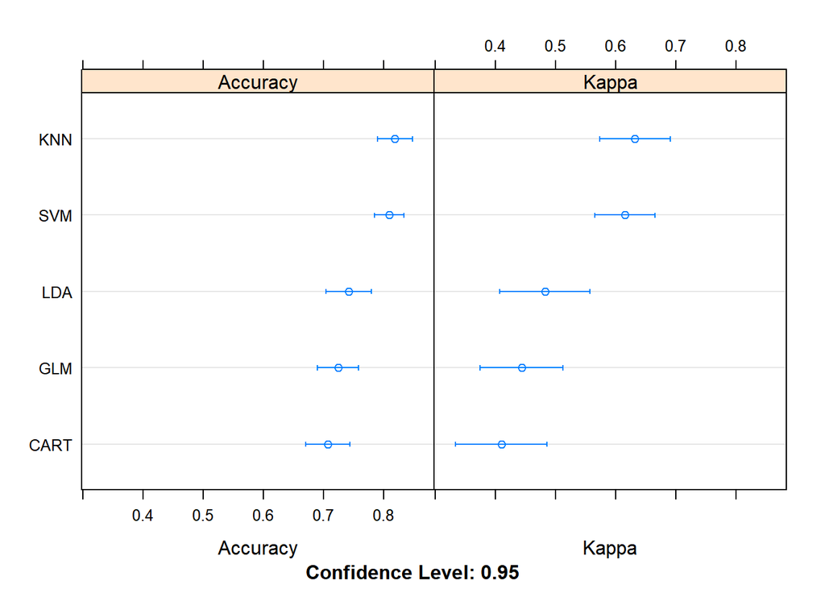

```r
dotplot(results)
```

## 5. Improve Accuracy

After we achieve a short list of machine learning algorithms with good level of accuracy, we can leverage ways to improve the accuracy of the models:

- Search for a combination of parameters for each algorithm using caret that yields the best results.
- Combine the prediction of multiple models into an ensemble prediction using standalone algorithms or the caretEnsemble package.

### 5.a) Algorithm Tuning

```r
set.seed(seed_num)
grid <- expand.grid(.sigma=c(0.01,0.025,0.05,0.075,0.1), .C=c(1))
fit.svm <- train(Class~., data=dataset, method="svmRadial", metric=metricTarget, tuneGrid=grid, trControl=control)
print(fit.svm)
```

```
## Support Vector Machines with Radial Basis Function Kernel
##
## 208 samples
##  60 predictor
##   2 classes: 'M', 'R'
##
## No pre-processing
## Resampling: Cross-Validated (10 fold, repeated 3 times)
## Summary of sample sizes: 187, 187, 187, 187, 188, 187, ...
## Resampling results across tuning parameters:
##
##   sigma  Accuracy   Kappa
##   0.010  0.8095310  0.6153152
##   0.025  0.8477489  0.6914002
##   0.050  0.8446320  0.6830552
##   0.075  0.8156421  0.6203854
##   0.100  0.7803102  0.5442697
##
## Tuning parameter 'C' was held constant at a value of 1
## Accuracy was used to select the optimal model using the largest value.
## The final values used for the model were sigma = 0.025 and C = 1.
```

### 5.b) Ensembles

```r
# Not applicable for this iteration of the project.
```

## 6. Finalize Model

Once we have narrow down to a model that we believe can make accurate predictions on unseen data, we are ready to finalize it. Finalizing a model may involve sub-tasks such as:

- Using an optimal model tuned to make predictions on unseen data.
- Creating a standalone model using the tuned parameters
- Saving an optimal model to file for later use.

### 6.a) Predictions on validation dataset

```r
# Not applicable for this iteration of the project.
```

### 6.b) Create standalone model on entire training dataset

```r
# Not applicable for this iteration of the project.
```

### 6.c) Save model for later use

```r
# Not applicable for this iteration of the project.
```